# Cloud Computing MY472 Week 3

October 15, 2019

## Cloud Computing

## Cloud Computing

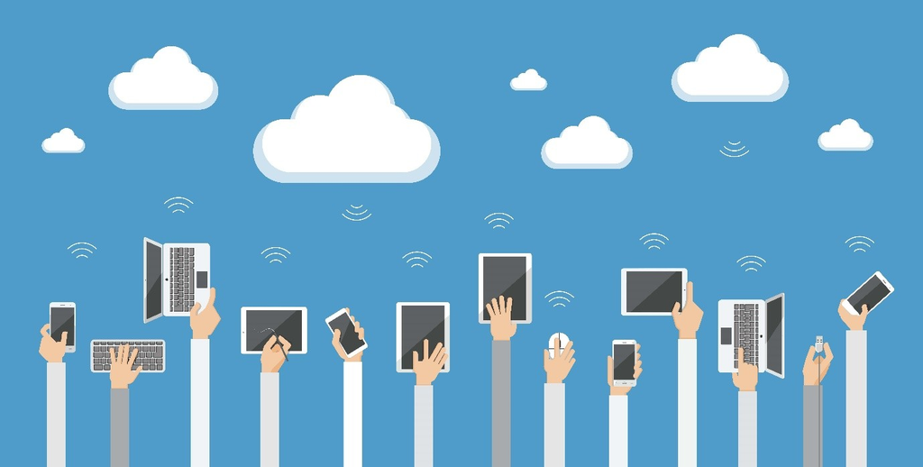

## Senario

- Suppose that you want to run a deep learning project
- This could require a lot of computing resources
  - processing power, maybe GPUs
  - memory/RAM
  - disk space and direct access to databases

So…

## Let’s buy a powerful comptuer!

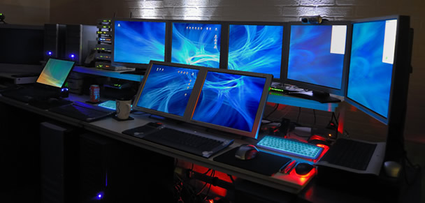

I can analyze anything!

## But this is what happens…

- Your computation environment is fixed
- Your demand fluctuates

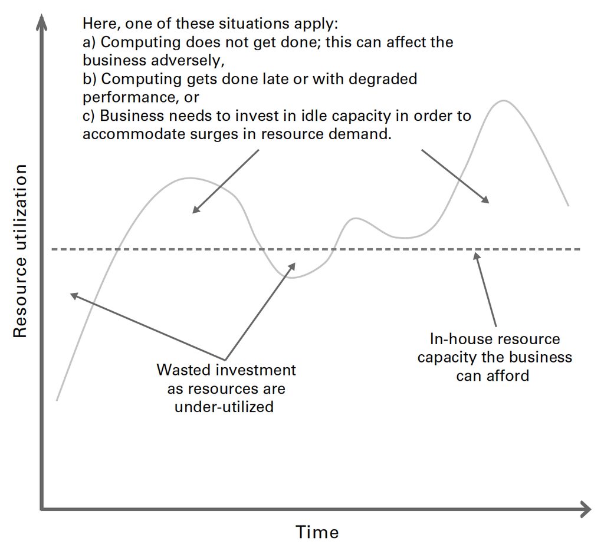

## Also, all sorts of things can go wrong…

- Hardware can break down
- Software needs constant updating, securituy patches, etc
- Internet connections can be faulty
- (Physical) security concerns have to be met

## So what if…

- You just have to pay what you use?
- You can deploy things in the matter of hours/minutes/seconds?

That’s what cloud computing is for!

## What is cloud computing?

## Your previous experience?

- Experience in Linux/Unix console?
- Experience use virtual machine softwares on your computer (e.g. VirtualBox, Parallels)?
- Having account on major cloud platforms (AWS, Microsoft Azure, Google Cloud)?
- Ever used HPC environments?

## You are already using cloud application services

These are the examples of Software as a Service:

- email
  - gmail
  - exchange mail
- storage
  - Google drive
  - Dropbox
- software
  - Google docs
  - Adobe

## Definition

“Cloud computing is a model for enabling ubiquitous, convenient, on-demand network access to a shared pool of configurable computing resources (e.g., networks, servers, storage, applications, and services) that can be rapidly provisioned and released with minimal management effort or service provider interaction. This cloud model promotes availability and is composed of five essential characteristics, three service models, and four deployment models.” (From [*NIST Definition of Cloud Computing*](https://csrc.nist.gov/publications/detail/sp/800-145/final))

## “as a service” models

Three main categories of cloud computing as a service:

- Software-as-a-service is a software distribution model in which applications are remotely hosted and served to users via the Internet, usually through a standard web browser
- infrastructure as a service (IaaS): a cloud provider hosts the infrastructure components traditionally present in an on-premises data center, including servers, storage and networking hardware. Includes a variety of associated services such as backup, log maintenance, updates, security, etc. Examples: AWS, Google Cloud, Azure.
- platform as a service (PaaS): a third-party provider delivers hardware and software tools – usually those needed for application development – to users over the internet

Beyond the use of cloud services, we will try to learn about and deploy the cloud computation resources

## Metaphor with pizza

[figure not shown]

## Technical perspective: Virtualisation

- In cloud computing, computers are virtualized
  - Similar idea to virtual machine on your computer
  - In data centers connected to the network, there are a number of hardwares which host a number of virtual machines

[figure not shown]

## Data centers

- For major providers of cloud service, there are data centers everywhere and you can deploy resources in any location.

**Example AWS**

[figure not shown]

## Data centers

- Physial locations of data centers are usually undisclosed (for security reasons)

[figure not shown]

## Technical Perspective: Virtualisation

**Difference between virtualisation on your machine and cloud**

- elasticity
  - readily **scalable** in short time
- measured service provision
  - billed based on the usage (e.g. CPU/memory/storage/network)

## Managed cloud service providers

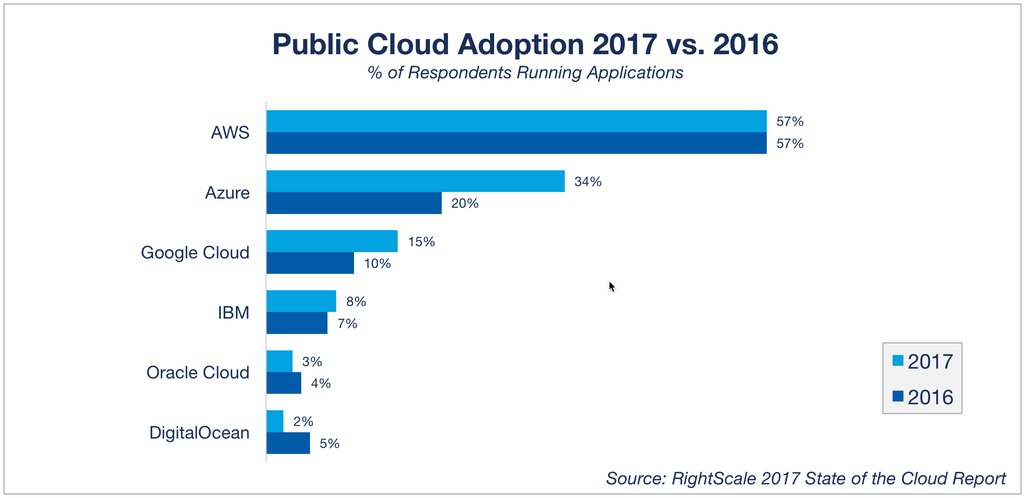

From [*4mation*](https://www.4mation.com.au/service/cloud-services/)

## Conceptual perspective: Level of abstraction

To what extent, you want a service provider to be responsible?  
(aaS = as a Service)

- Infrastructure? (IaaS)
- Platform (= OS)? (PaaS)
- Software (SaaS)

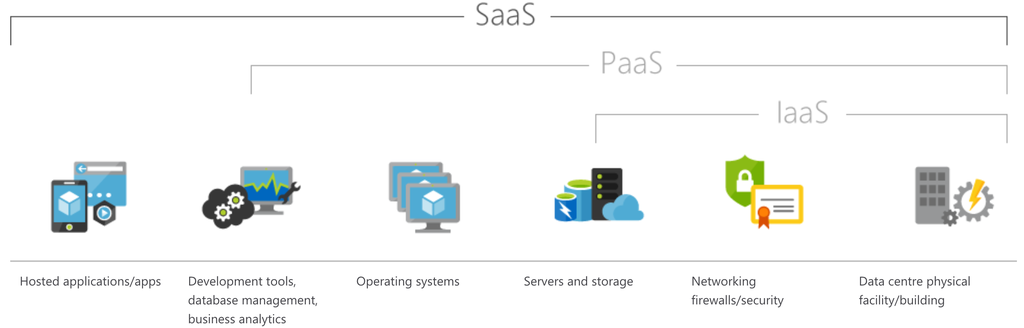

- Data storage
  - Store important data reliably and securely
- Computation
  - Set up a virtual machine and run a computationally intensive tasks
    - Jupyter notebook server
    - RStudio server
- Data acquisition
  - Stream tweets (although it’s sort of discontinued)
  - Create a crawler to regularly check news websites
- Database hosting
  - Set up databases online

## Advantages and disadvantages of cloud computing

## Cloud computing: Advantages

- Availability
  - In a given time, what’s the chance that the service is available?
- Durability
  - What’s the chance of losing the data?
- Scalability
  - deploy the same app on a bigger instances
  - set up auto-scaling with load balancers
- Cost efficiency
- Security

## Advantages: Scalability

Definition: “The ability for something designed to operate at one measure of size to operate successfully at other sizes. The term is commonly used in relation to the development of shared computer applications that are intended to be used by large numbers of users. Of necessity, developments take place with a small number of test users. Unless the application is carefully designed to take account of the interactions that will arise when it is called on to service a large number of users, it may well fail to operate at all, or to operate only with an unacceptable level of service. An application that successfully expands its numbers of supported users is said to be scalable.”

(From the *Oxford Dictionary of Computer Science*)

Simply put, the question is whether the computational system you have created can seamlessly scale up?

## Examples from AWS

- Relational Database Service (RDS): https://aws.amazon.com/rds/
- DynamoDB: https://aws.amazon.com/dynamodb/
- [“Scaling up to your first 10 million users”](https://www.youtube.com/watch?v=ccojvcQq858) (YouTube)

## Advantages: Cost efficiency

- In many cases, it is cheaper to use cloud computing services
  - You may need to use high performance computing for a few times
- Total cost of ownership (TCO) model
  - https://aws.amazon.com/tco-calculator/
  - [Three costs of onwership](https://www.forbes.com/sites/moorinsights/2016/04/11/tco-analysis-demonstrates-how-moving-to-the-cloud-can-save-your-company-money/)
    - **Capital expenses**: On-premises hardware & software
    - **Operating expenses**: Services, support & maintenance fees to keep the equipment running
    - **Indirect costs**: Potential downtime and time-to-market delays

## Advantages: Security

When you use cloud services, some of the security concerns (security “of” the cloud) are taken care by the service providers.

For example:

- Update computer systems
- Automated backup
- Network connection in the cloud
- Physical security of infrastructure

However, you also are responsible for other concerns

- Network connection between client and cloud
- Data encryption
- Application security

## Cloud computing: Disadvantages

- Cost?
  - Some of the costs of cloud is for availability, but do you need a highly available application?
- Communication with the cloud
  - Unless you prepare dedicate line to connect to the cloud, your communication with the cloud is going through the Internet.
    - reliable?
    - secure? (encryption, direct connect)
- Service providers’ problem
- Legal compliance
  - e.g. GDPR requirement of encryption, data security, data physical location

## Cloud trend: Going serverless

## Severless computing

- So far what we have seen is based on the idea of “replacing what you have done with cloud service”
- Serverless computing goes one step further

## Web app with servers example

[Link](https://cacoo.com/templates/aws-diagram-software)

[figure not shown]

## Serverless example

[Link](https://dev.to/connor11528/tutorial-for-building-a-web-application-with-amazon-s3-lambda-dynamodb-and-api-gateway)

[figure not shown]

## Advantages and disadvantages of serverless computing

**Advantages**

- Good for real time insights
- Scalable (instantly)
- Usually cheaper

**Disadvantages**

- New/unfamiliar idea
- Not for memory intensive tasks
- Not really suited for tasks that takes long time to process (e.g. 5min limit for AWS Lambda)

## Severless computing services

The core of serverless computing is a service to execute tasks without a server

- AWS Lambda
- Azure “Functions”
- Google Cloud “Functions”

## Internet of Things (IoT)

## Definition

The internet of things, or IoT, is a system of interrelated computing devices, mechanical and digital machines, objects, animals or people that are provided with unique identifiers (UIDs) and the ability to transfer data over a network without requiring human-to-human or human-to-computer interaction.

From [*Tech Target*](https://internetofthingsagenda.techtarget.com/definition/Internet-of-Things-IoT)

## IoT: Illustration

[figure not shown]

## Cloud and IoT

- IoT: A number of objects have sensors and send the data to cloud.
- Cloud: Aggregation of data from object, generate insights, send them to your devices (e.g. computer/smartphone)
- Example: Healthcare (Botta et al, 2016)
  - “collecting patients’ vital data via a network of sensors connected to medical devices, delivering the data to a medical center’s Cloud for storage and processing, properly managing information provided by sensors, or guaranteeing ubiquitous access to, or sharing of, medical data as Electronic Healthcare Records (EHR)”

## Week 3 Lab

In the lab, we will see the general overview of Amazon Web Service, and then in the lab, we will actually do some work with AWS.

**Before the lab**

- Accept the invitation to the AWS Educate classroom (create AWS Educate Starter Account)
  - This account will let you play with AWS without risk (i.e. account compromised)
- For Windows users, install git from https://git-scm.com/download/win
  - We need **bash for git**